# 002.003_CIFAR 10 CNN VGG16

## Image classification via Convolutional Neural Network

Image classification via Convolutional Neural Network (CNN) The following analysis describes different models

In this work we investigate the effect of the convolutional network depth on its accuracy in the large-scale image recognition setting. Our main contribution is a thorough evaluation of networks of increasing depth using an architecture with very small (3x3) convolution filters, which shows that a significant improvement on the prior-art configurations can be achieved by pushing the depth to 16-19 weight layers. These findings were the basis of our ImageNet Challenge 2014 submission, where our team secured the first and the second places in the localisation and classification tracks respectively.

### Data collection

The CIFAR-10 dataset consists of 60000 32x32 colour images in 10 classes, with 6000 images per class.  
There are 50000 training images and 10000 test images.  
The dataset is divided into five training batches and one test batch, each with 10000 images. The test batch contains exactly 1000 randomly-selected images from each class. The training batches contain the remaining images in random order, but some training batches may contain more images from one class than another. Between them, the training batches contain exactly 5000 images from each class.

**DataSet:** [CIFAR 10](https://www.cs.toronto.edu/~kriz/cifar.html)

### References:

- Karen Simonyan, Andrew Zisserman:  
  **Very Deep Convolutional Networks for Large-Scale Image Recognition**  
  [Very Deep Convolutional Networks for Large-Scale Image Recognition](https://arxiv.org/abs/1409.1556)
- Sergey Ioffe, Christian Szegedy  
  **Batch Normalization**  
  [Batch Normalization](https://arxiv.org/abs/1502.03167)
- Alex Krizhevsky, 2009  
  **Learning Multiple Layers of Features from Tiny Images**  
  [Learning Multiple Layers of Features from Tiny Images](https://www.cs.toronto.edu/~kriz/cifar.html)
- ImageNet pretrained Weights  
  [Imagenet](https://www.cs.toronto.edu/~kriz/cifar.html)

```python
import keras
from keras import models, layers, regularizers, optimizers
from keras.models import Sequential

from keras.preprocessing.image import ImageDataGenerator
from keras.datasets import cifar10
from keras.utils import to_categorical
from keras.callbacks import ModelCheckpoint

import tensorflow as tf

import os
import numpy as np

import matplotlib
import matplotlib.pyplot as plt

from utils.dataloader import maybe_download_and_extract, get_data_set, Cifar10_DataPreparation

import model.VGG
from model.VGG import VGG

from utils.config import get_config_from_json
```

```python
# Definitions
# ===================================================================

_, config_dict = get_config_from_json('configs/imageprocessing.json')

# Number of colour channels for the images: 1 channel for gray-scale.
num_channels = config_dict['cifar_VGG']['num_channels']

# Number of classes, one class for each of 10 digits.
num_classes = config_dict['cifar_VGG']['num_classes']

# Number of epochs
epochs = config_dict['cifar_VGG']['num_epochs']

# Number of max epochs
max_epochs = config_dict['cifar_VGG']['maxepoches']

batch_size = config_dict['cifar_VGG']['batch_size']

learning_rate = config_dict['cifar_VGG']['learning_rate']
learning_rate_decay = config_dict['cifar_VGG']['learning_rate_decay']

# datashape = (32, 32, 3)
```

```python
print('num_channels: {}'.format(num_channels))
print('num_classes: {}'.format(num_classes))

print('epochs: {}'.format(epochs))
print('max_epochs: {}'.format(max_epochs))

print('batch_size: {}'.format(batch_size))

print('learning_rate: {}'.format(learning_rate))
print('learning_rate_decay: {}'.format(learning_rate_decay))
```

```
num_channels: 3
num_classes: 10
epochs: 10
max_epochs: 250
batch_size: 128
learning_rate: 0.0001
learning_rate_decay: 1e-06
```

```python
print('Keras: {}'.format(keras.__version__))
print('Tensorflow: {}'.format(tf.VERSION))

matplotlib.style.use('ggplot')
```

```
Keras: 2.1.4
Tensorflow: 1.6.0
```

```python
# load train and test data

validation = True;
x_train, y_train, x_test, y_test, x_val, y_val = Cifar10_DataPreparation(num_classes, validation = validation)
```

```
Train data (40000, 32, 32, 3)
Test data (10000, 32, 32, 3)
Val data (10000, 32, 32, 3)
```

```python
labels = {0: 'airplane', 1:'automobile', 2:'bird', 3:'cat', 4: 'deer', 5:'dog', 6:'frog', 7:'horse', 8:'ship', 9:'truck'}
```

[output not shown]

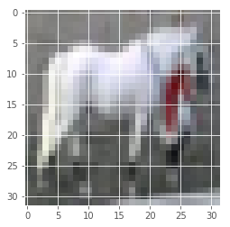

```python
import random
idx = random.randint(1,40000)

img = np.array(x_train[idx])
imgplot = plt.imshow(img)
label = y_train[idx]

print(labels[label[0]])
```

## Very deep convolutional networks for large-scale image recognition

### VGG16 Model

```python
def model_VGG16(datashape = (32, 32, 3), num_classes = 10, show = True, path = None):
    '''
    Build the network of vgg for 10 classes with dropout and weight decay as described in the paper
    "Very deep convolutional networks for large-scale image recognition"

    Model Schema is based on
    [Model Schema][1]

    Batch Normalization:
    [Batch Normalization][2]

    ImageNet pretrained Weights
    [Imagenet][3]

    [1]: https://arxiv.org/abs/1409.1556
    [2]: https://arxiv.org/abs/1502.03167
    [3]: https://drive.google.com/file/d/0Bz7KyqmuGsilT0J5dmRCM0ROVHc/view?usp=sharing

    param:  datashape   - shape of the imput data
            num_classes - number of classes to predict
            path        - to pretrained model

    return: model instance
    '''

    model = Sequential()
    model.add(layers.Conv2D(64, (3, 3), padding='same', activation = 'relu', input_shape = datashape))
    model.add(layers.BatchNormalization())
    model.add(layers.Dropout(0.3))

    model.add(layers.Conv2D(64, (3, 3), padding='same', activation = 'relu'))
    model.add(layers.BatchNormalization())

    model.add(layers.MaxPooling2D(pool_size=(2, 2)))

    model.add(layers.Conv2D(128, (3, 3), padding='same', activation = 'relu'))
    model.add(layers.BatchNormalization())
    model.add(layers.Dropout(0.4))

    model.add(layers.Conv2D(128, (3, 3), padding='same', activation = 'relu'))
    model.add(layers.BatchNormalization())

    model.add(layers.MaxPooling2D(pool_size=(2, 2)))

    model.add(layers.Conv2D(256, (3, 3), padding='same', activation = 'relu'))
    model.add(layers.BatchNormalization())
    model.add(layers.Dropout(0.4))

    model.add(layers.Conv2D(256, (3, 3), padding='same', activation = 'relu'))
    model.add(layers.BatchNormalization())
    model.add(layers.Dropout(0.4))

    model.add(layers.Conv2D(256, (3, 3), padding='same', activation = 'relu'))
    model.add(layers.BatchNormalization())

    model.add(layers.MaxPooling2D(pool_size=(2, 2)))

    model.add(layers.Conv2D(512, (3, 3), padding='same', activation = 'relu'))
    model.add(layers.BatchNormalization())
    model.add(layers.Dropout(0.4))

    model.add(layers.Conv2D(512, (3, 3), padding='same', activation = 'relu'))
    model.add(layers.BatchNormalization())
    model.add(layers.Dropout(0.4))

    model.add(layers.Conv2D(512, (3, 3), padding='same', activation = 'relu'))
    model.add(layers.BatchNormalization())

    model.add(layers.MaxPooling2D(pool_size=(2, 2)))

    model.add(layers.Conv2D(512, (3, 3), padding='same', activation = 'relu'))
    model.add(layers.BatchNormalization())
    model.add(layers.Dropout(0.4))

    model.add(layers.Conv2D(512, (3, 3), padding='same', activation = 'relu'))
    model.add(layers.BatchNormalization())
    model.add(layers.Dropout(0.4))

    model.add(layers.Conv2D(512, (3, 3), padding='same', activation = 'relu'))
    model.add(layers.BatchNormalization())

    model.add(layers.MaxPooling2D(pool_size=(2, 2)))
    model.add(layers.Dropout(0.5))

    model.add(layers.Flatten())
    model.add(layers.Dense(512, activation = 'relu'))
    model.add(layers.BatchNormalization())

    model.add(layers.Dropout(0.5))
    model.add(layers.Dense(num_classes, activation = 'softmax'))

    if path != None:
        # Loads ImageNet pre-trained data
        model.load_weights(path)

    if show:
        model.summary()

    return model
```

### Support Functions

```python
def decode(data):
    '''
    Decode one hot encoded array

    Arguments:
    data   - one hot encoded array

    return - int number
    '''
    return np.argmax(data)
```

```python
def decodeArray(encoded_data):
    arr = np.array([])

    for i in range(encoded_data.shape[0]):
        decoded_item = decode(encoded_data[i])
        arr = np.append(arr, decoded_item)

    arr = arr.astype('int32')
    return arr
```

```python
def encode(data, num_classes):
    '''
    Encode int number to one hot array

    Arguments:
    data   - int number

    return - one hot array
    '''
    return to_categorical(data, num_classes = num_classes)
```

```python
def plot_model(model_details):

    # Create sub-plots
    fig, axs = plt.subplots(1,2,figsize=(15,5))

    # Summarize history for accuracy
    axs[0].plot(range(1,len(model_details.history['acc'])+1),model_details.history['acc'])
    axs[0].plot(range(1,len(model_details.history['val_acc'])+1),model_details.history['val_acc'])
    axs[0].set_title('Model Accuracy')
    axs[0].set_ylabel('Accuracy')
    axs[0].set_xlabel('Epoch')
    axs[0].set_xticks(np.arange(1,len(model_details.history['acc'])+1),len(model_details.history['acc'])/10)
    axs[0].legend(['train', 'val'], loc='best')

    # Summarize history for loss
    axs[1].plot(range(1,len(model_details.history['loss'])+1),model_details.history['loss'])
    axs[1].plot(range(1,len(model_details.history['val_loss'])+1),model_details.history['val_loss'])
    axs[1].set_title('Model Loss')
    axs[1].set_ylabel('Loss')
    axs[1].set_xlabel('Epoch')
    axs[1].set_xticks(np.arange(1,len(model_details.history['loss'])+1),len(model_details.history['loss'])/10)
    axs[1].legend(['train', 'val'], loc='best')

    # Show the plot
    plt.show()
```

#### Buikd Model

```python
model = model_VGG16(datashape = (32, 32, 3), num_classes = 10, show = True, path = None)
```

```
_________________________________________________________________
Layer (type)                 Output Shape              Param #
=================================================================
conv2d_40 (Conv2D)           (None, 32, 32, 64)        1792
_________________________________________________________________
batch_normalization_43 (Batc (None, 32, 32, 64)        256
_________________________________________________________________
dropout_31 (Dropout)         (None, 32, 32, 64)        0
_________________________________________________________________
conv2d_41 (Conv2D)           (None, 32, 32, 64)        36928
_________________________________________________________________
batch_normalization_44 (Batc (None, 32, 32, 64)        256
_________________________________________________________________
max_pooling2d_16 (MaxPooling (None, 16, 16, 64)        0
_________________________________________________________________
conv2d_42 (Conv2D)           (None, 16, 16, 128)       73856
_________________________________________________________________
batch_normalization_45 (Batc (None, 16, 16, 128)       512
_________________________________________________________________
dropout_32 (Dropout)         (None, 16, 16, 128)       0
_________________________________________________________________
conv2d_43 (Conv2D)           (None, 16, 16, 128)       147584
_________________________________________________________________
batch_normalization_46 (Batc (None, 16, 16, 128)       512
_________________________________________________________________
max_pooling2d_17 (MaxPooling (None, 8, 8, 128)         0
_________________________________________________________________
conv2d_44 (Conv2D)           (None, 8, 8, 256)         295168
_________________________________________________________________
batch_normalization_47 (Batc (None, 8, 8, 256)         1024
_________________________________________________________________
dropout_33 (Dropout)         (None, 8, 8, 256)         0
_________________________________________________________________
conv2d_45 (Conv2D)           (None, 8, 8, 256)         590080
_________________________________________________________________
batch_normalization_48 (Batc (None, 8, 8, 256)         1024
_________________________________________________________________
dropout_34 (Dropout)         (None, 8, 8, 256)         0
_________________________________________________________________
conv2d_46 (Conv2D)           (None, 8, 8, 256)         590080
```

[output cut: 42 more lines]

```
_________________________________________________________________
flatten_4 (Flatten)          (None, 512)               0
_________________________________________________________________
dense_7 (Dense)              (None, 512)               262656
_________________________________________________________________
batch_normalization_56 (Batc (None, 512)               2048
_________________________________________________________________
dropout_40 (Dropout)         (None, 512)               0
_________________________________________________________________
dense_8 (Dense)              (None, 10)                5130
=================================================================
Total params: 15,001,418
Trainable params: 14,991,946
Non-trainable params: 9,472
_________________________________________________________________
```

```python
model.compile(loss='categorical_crossentropy', optimizer = 'rmsprop', metrics=['accuracy'])

max_epochs = 20
```

```python
history = model.fit(x_train, y_train,
                    batch_size = batch_size,
                    epochs = max_epochs,
                    validation_data = (x_val, y_val),
                    verbose = 1)
```

```
Train on 40000 samples, validate on 10000 samples
```

```python
model.save('model/weights/modelVGG16.h5')
```

```python
scores = model.evaluate(x_test, y_test, verbose=0)
print("Accuracy: %.2f%%" % (scores[1]*100))
```

```
Accuracy: 82.45%
```

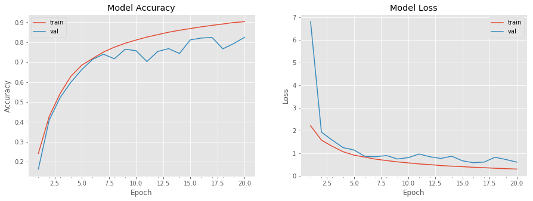

```python
plot_model(history)
```

### Callbacks

When training a model, there are many things you can’t predict from the start. In particular, you can’t tell how many epochs will be needed to get to an optimal validation loss.

A much better way to handle this is to stop training when you measure that the validation loss in no longer improving. This can be achieved using a Keras callback. A callback is an object (a class instance implementing specific methods) that is passed to the model in the call to fit and that is called by the model at various points during training. It has access to all the available data about the state of the model and its performance, and it can take action: interrupt training, save a model, load a different weight set, or otherwise alter the state of the model.

```python
def ModelCheckPoint(modelname = 'mymodel.h5'):

    '''
    Define a callback checkpoint

    Arguments: modelname of the best model saved
    return:    callback function as a list

    '''

    callback = ModelCheckpoint(filepath = modelname,  # model filename
                                 monitor = 'val_loss',   # quantity to monitor
                                 verbose = 0,            # verbosity - 0 or 1
                                 save_best_only = True,  # The latest best model will not be overwritten
                                 mode = 'auto')          # The decision to overwrite model is made
                                                         # automatically depending on the quantity to monitor
    return [callback]
```

```python
def EarlyStopping():

    '''
    Define a callback

    Arguments: modelname of the best model saved
    return:    callback function as a list

    '''

    callback = EarlyStopping(monitor = 'acc', patience = 1,)

    return [callback]
```

```python
def ReduceLROnPlateau():

    '''
    Define a callback

    Arguments: modelname of the best model saved
    return:    callback function as a list

    '''
    callback = ReduceLROnPlateau(monitor  = 'val_loss',
                                 patience = 10,
                                 verbose  = 1,
                                 factor   = 0.1,
                                 min_lr   = 0.00001)

    return [callback]
```

```python
from keras.callbacks import ModelCheckpoint, EarlyStopping, LearningRateScheduler, ReduceLROnPlateau

checkpoint        = ModelCheckPoint(modelname = 'model/weights/modelCIFAR10_VGG16.h5')
reducelronplateau = ReduceLROnPlateau()
earlystopping     = EarlyStopping()
```

### Model with data augmentation

```python
datagen = ImageDataGenerator(featurewise_center = False,             # set input mean to 0 over the dataset
                             samplewise_center = False,              # set each sample mean to 0
                             featurewise_std_normalization = False,  # divide inputs by std of the dataset
                             samplewise_std_normalization = False,   # divide each input by its std
                             zca_whitening = False,                  # apply ZCA whitening
                             rotation_range = 10,                    # randomly rotate images in the range (degrees, 0 to 180)
                             width_shift_range = 0.1,                # randomly shift images horizontally (fraction of total width)
                             height_shift_range = 0.1,               # randomly shift images vertically (fraction of total height)
                             horizontal_flip = False,                # randomly flip images
                             vertical_flip = False)                  # randomly flip images

datagenerator = datagen.flow(x_train, y_train, batch_size = batch_size)
```

```python
augmented_model = model_VGG16(datashape = (32, 32, 3), num_classes = 10, show = True, path = None)
```

```
_________________________________________________________________
Layer (type)                 Output Shape              Param #
=================================================================
conv2d_53 (Conv2D)           (None, 32, 32, 64)        1792
_________________________________________________________________
batch_normalization_57 (Batc (None, 32, 32, 64)        256
_________________________________________________________________
dropout_41 (Dropout)         (None, 32, 32, 64)        0
_________________________________________________________________
conv2d_54 (Conv2D)           (None, 32, 32, 64)        36928
_________________________________________________________________
batch_normalization_58 (Batc (None, 32, 32, 64)        256
_________________________________________________________________
max_pooling2d_21 (MaxPooling (None, 16, 16, 64)        0
_________________________________________________________________
conv2d_55 (Conv2D)           (None, 16, 16, 128)       73856
_________________________________________________________________
batch_normalization_59 (Batc (None, 16, 16, 128)       512
_________________________________________________________________
dropout_42 (Dropout)         (None, 16, 16, 128)       0
_________________________________________________________________
conv2d_56 (Conv2D)           (None, 16, 16, 128)       147584
_________________________________________________________________
batch_normalization_60 (Batc (None, 16, 16, 128)       512
_________________________________________________________________
max_pooling2d_22 (MaxPooling (None, 8, 8, 128)         0
_________________________________________________________________
conv2d_57 (Conv2D)           (None, 8, 8, 256)         295168
_________________________________________________________________
batch_normalization_61 (Batc (None, 8, 8, 256)         1024
_________________________________________________________________
dropout_43 (Dropout)         (None, 8, 8, 256)         0
_________________________________________________________________
conv2d_58 (Conv2D)           (None, 8, 8, 256)         590080
_________________________________________________________________
batch_normalization_62 (Batc (None, 8, 8, 256)         1024
_________________________________________________________________
dropout_44 (Dropout)         (None, 8, 8, 256)         0
_________________________________________________________________
conv2d_59 (Conv2D)           (None, 8, 8, 256)         590080
```

[output cut: 42 more lines]

```
_________________________________________________________________
flatten_5 (Flatten)          (None, 512)               0
_________________________________________________________________
dense_9 (Dense)              (None, 512)               262656
_________________________________________________________________
batch_normalization_70 (Batc (None, 512)               2048
_________________________________________________________________
dropout_50 (Dropout)         (None, 512)               0
_________________________________________________________________
dense_10 (Dense)             (None, 10)                5130
=================================================================
Total params: 15,001,418
Trainable params: 14,991,946
Non-trainable params: 9,472
_________________________________________________________________
```

```python
augmented_model.compile(loss='categorical_crossentropy', optimizer = 'rmsprop', metrics=['accuracy'])
maxepochs = 20
```

```python
augmented_model_details = augmented_model.fit_generator(datagenerator,
                                                        steps_per_epoch = len(x_train) // batch_size, # number of samples per gradient update
                                                        epochs = maxepochs, # number of iterations
                                                        validation_data= (x_val, y_val),
                                                        callbacks= checkpoint,
                                                        verbose=1)
```

```python
augmented_model.save('model/weights/augmented_modelVGG16.h5')
```

```python
scores = model.evaluate(x_test, y_test, verbose=0)
print("Accuracy: %.2f%%" % (scores[1]*100))
```

```
Accuracy: 82.45%
```

```python
# opt = optimizer('rmsprop', learning_rate, learning_rate_decay)
model.compile(loss='categorical_crossentropy', optimizer = 'rmsprop', metrics=['accuracy'])
```

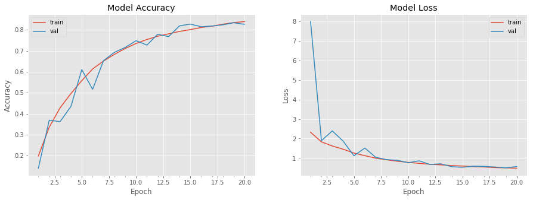

```python
plot_model(augmented_model_details)
```